# TASK #1: PROJECT OVERVIEW

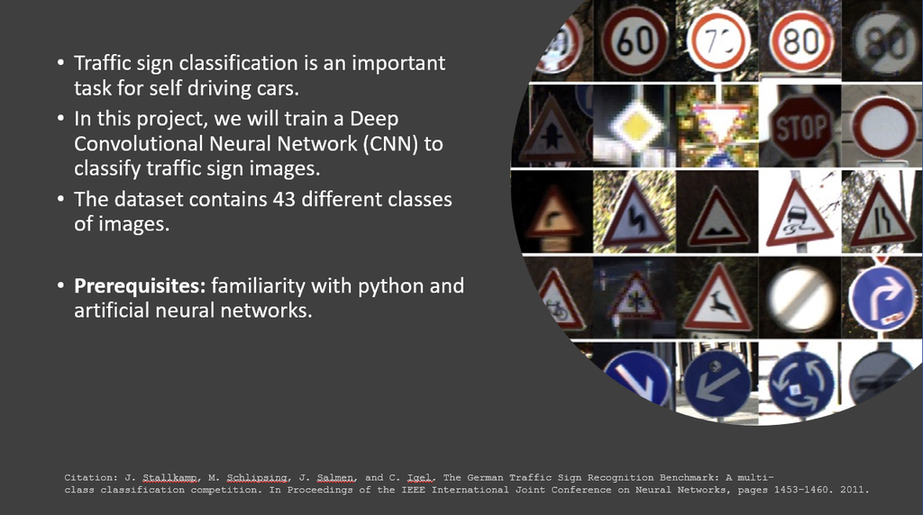

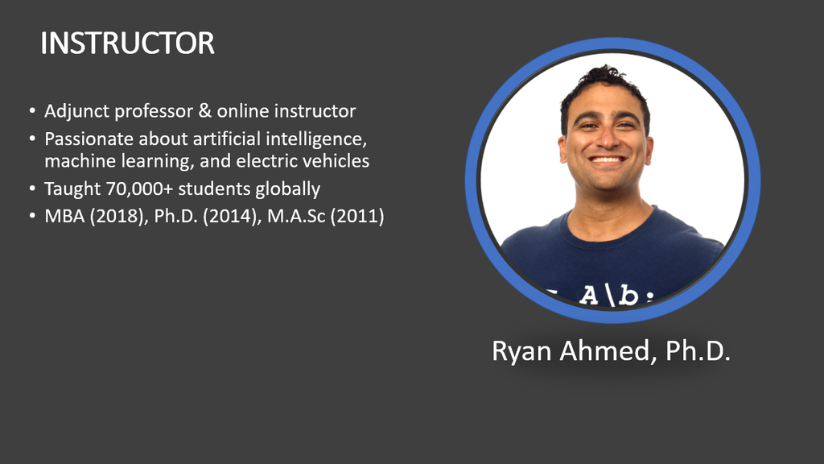

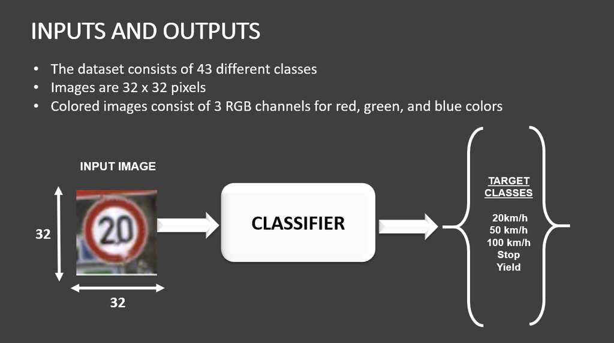

# TASK #2: IMPORT LIBRARIES/DATASETS

```python
import matplotlib.pyplot as plt
import numpy as np
import tensorflow as tf
import pandas as pd
import seaborn as sns
import pickle
import random
```

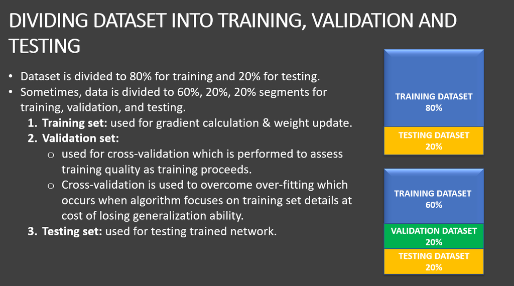

```python
with open("./train.p", mode='rb') as training_data:
    train = pickle.load(training_data)
with open("./valid.p", mode='rb') as validation_data:
    valid = pickle.load(validation_data)
with open("./test.p", mode='rb') as testing_data:
    test = pickle.load(testing_data)
```

```python
valid.keys()
```

```
dict_keys(['coords', 'labels', 'features', 'sizes'])
```

```python
X_train=train['features']
X_val=valid['features']
X_test=test['features']
Y_train=train['labels']
Y_val=valid['labels']
Y_test=test['labels']
```

```python
X_train[0]
```

```
array([[[28, 25, 24],
        [27, 24, 23],
        [27, 24, 22],
        ...,
        [32, 28, 24],
        [31, 27, 25],
        [31, 27, 26]],

       [[29, 26, 25],
        [27, 25, 23],
        [27, 25, 23],
        ...,
        [32, 28, 24],
        [31, 27, 24],
        [30, 27, 25]],

       [[28, 26, 26],
        [27, 25, 23],
        [26, 25, 23],
        ...,
        [32, 28, 24],
        [31, 27, 24],
        [30, 27, 25]],

       ...,

       [[27, 24, 23],
        [28, 25, 24],
        [30, 25, 24],
        ...,
        [27, 24, 23],
        [28, 24, 22],
        [29, 25, 22]],

       [[28, 23, 23],
        [29, 24, 24],
        [31, 25, 24],
        ...,
        [27, 24, 23],
        [28, 24, 22],
        [28, 24, 21]],

       [[29, 23, 23],
        [30, 24, 24],
        [32, 24, 23],
        ...,
        [27, 24, 22],
        [27, 23, 21],
        [26, 22, 20]]], dtype=uint8)
```

# TASK #3: PERFORM IMAGES VISUALIZATION

```
2
```

[figure not shown]

```python
i = np.random.randint(1, len(X_train))
plt.imshow(X_train[i])
Y_train[i]
```

# TASK #4: CONVERT IMAGES TO GRAYSCALE AND PERFORM NORMALIZATION

```python
from sklearn.utils import shuffle
X_train, Y_train = shuffle(X_train, Y_train)
```

```python
x_train=np.mean(X_train,axis=-1)
x_train.shape
```

```
(34799, 32, 32)
```

```python
x_train=x_train/256
x_train[0]
```

```
array([[0.59765625, 0.59505208, 0.60026042, ..., 0.29817708, 0.31380208,
        0.41927083],
       [0.6015625 , 0.59505208, 0.59635417, ..., 0.31119792, 0.28515625,
        0.36458333],
       [0.59244792, 0.59765625, 0.59505208, ..., 0.2734375 , 0.25130208,
        0.34244792],
       ...,
       [0.39322917, 0.37109375, 0.37109375, ..., 0.29557292, 0.28776042,
        0.35416667],
       [0.41536458, 0.36848958, 0.38020833, ..., 0.41927083, 0.43098958,
        0.43880208],
       [0.3671875 , 0.36458333, 0.36979167, ..., 0.38541667, 0.38932292,
        0.39192708]])
```

```python
x_val=np.mean(X_val,axis=-1)
x_val=x_val/256
x_val[0]
```

```
array([[0.04817708, 0.04557292, 0.04557292, ..., 0.04817708, 0.046875  ,
        0.04557292],
       [0.04947917, 0.04557292, 0.04817708, ..., 0.046875  , 0.046875  ,
        0.04557292],
       [0.04947917, 0.04557292, 0.046875  , ..., 0.046875  , 0.046875  ,
        0.04557292],
       ...,
       [0.05989583, 0.05598958, 0.05859375, ..., 0.04817708, 0.05208333,
        0.05208333],
       [0.06510417, 0.06119792, 0.06510417, ..., 0.04427083, 0.04817708,
        0.05208333],
       [0.06901042, 0.06510417, 0.06901042, ..., 0.046875  , 0.05078125,
        0.05598958]])
```

```python
x_test=np.mean(X_test,axis=-1)
x_test=x_test/256
x_test[0]
```

```
array([[0.55859375, 0.55208333, 0.55729167, ..., 0.46223958, 0.47526042,
        0.41666667],
       [0.56380208, 0.55859375, 0.56380208, ..., 0.5703125 , 0.56510417,
        0.55989583],
       [0.5625    , 0.56510417, 0.5546875 , ..., 0.57682292, 0.57942708,
        0.57291667],
       ...,
       [0.54817708, 0.53776042, 0.54166667, ..., 0.54817708, 0.546875  ,
        0.55859375],
       [0.54427083, 0.54166667, 0.53385417, ..., 0.54036458, 0.54427083,
        0.54817708],
       [0.5390625 , 0.53255208, 0.54557292, ..., 0.546875  , 0.54947917,
        0.55208333]])
```

```python
X_train_gray=x_train
```

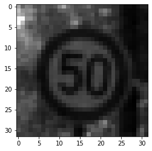

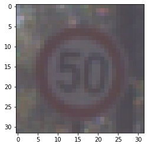

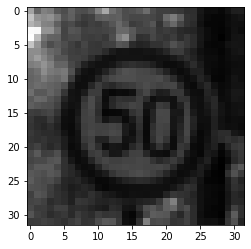

```python
i = random.randint(1, len(X_train_gray))
plt.imshow(X_train_gray[i].squeeze(), cmap = 'gray')
plt.figure()
plt.imshow(X_train[i])
plt.figure()
plt.imshow(x_train[i].squeeze(), cmap = 'gray')
```

# TASK #5: UNDERSTAND THE THEORY AND INTUITION BEHIND CONVOLUTIONAL NEURAL NETWORKS

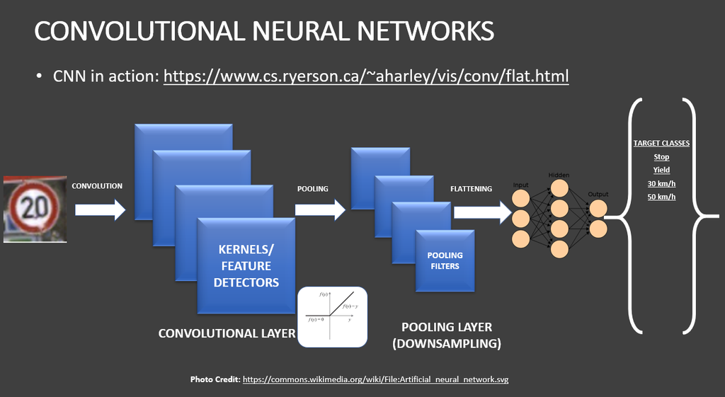

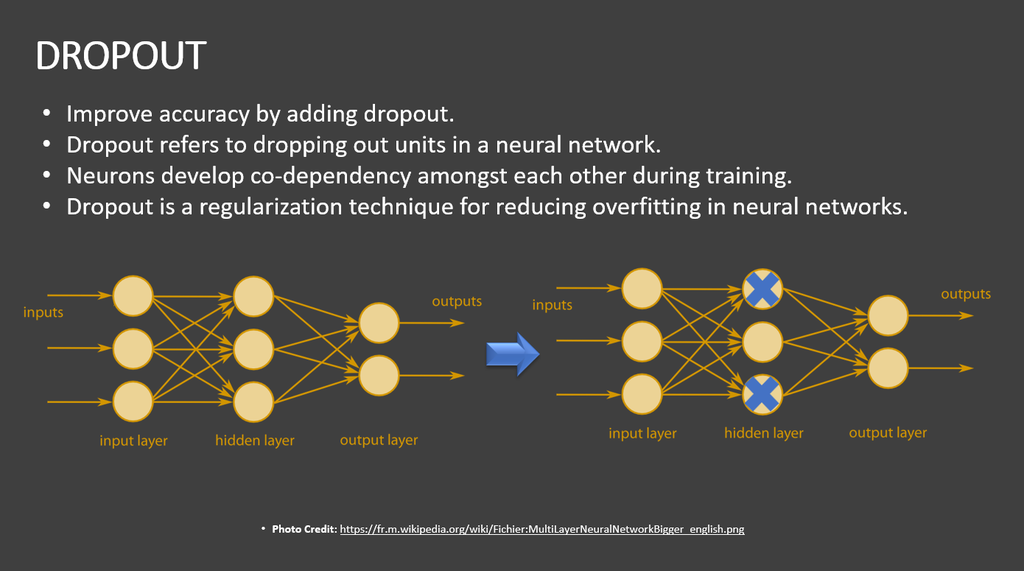

# TASK #6: BUILD DEEP CONVOLUTIONAL NEURAL NETWORK MODEL

```python
x_train=x_train.reshape(list(x_train.shape)+[1])
x_val=x_val.reshape(list(x_val.shape)+[1])
x_test=x_test.reshape(list(x_test.shape)+[1])
```

```python
from tensorflow.keras import datasets, layers, models

cnn=models.Sequential([
    layers.Conv2D(8,(5,5),activation='relu',input_shape=(32,32,1)),
    layers.MaxPooling2D(),
    layers.Conv2D(16,(5,5),activation='relu'),
    layers.MaxPooling2D(),
    layers.Flatten(),
    layers.Dense(128,activation='relu'),
    layers.Dropout(0.1),
    layers.Dense(64,activation='relu'),
    layers.Dense(43,activation='softmax')
])
```

```python
cnn.summary()
```

```
Model: "sequential"
_________________________________________________________________
Layer (type)                 Output Shape              Param #
=================================================================
conv2d (Conv2D)              (None, 28, 28, 8)         208
_________________________________________________________________
max_pooling2d (MaxPooling2D) (None, 14, 14, 8)         0
_________________________________________________________________
conv2d_1 (Conv2D)            (None, 10, 10, 16)        3216
_________________________________________________________________
max_pooling2d_1 (MaxPooling2 (None, 5, 5, 16)          0
_________________________________________________________________
flatten (Flatten)            (None, 400)               0
_________________________________________________________________
dense (Dense)                (None, 128)               51328
_________________________________________________________________
dropout (Dropout)            (None, 128)               0
_________________________________________________________________
dense_1 (Dense)              (None, 64)                8256
_________________________________________________________________
dense_2 (Dense)              (None, 43)                2795
=================================================================
Total params: 65,803
Trainable params: 65,803
Non-trainable params: 0
_________________________________________________________________
```

# TASK #7: COMPILE AND TRAIN DEEP CNN MODEL

```python
cnn.compile(
    loss='sparse_categorical_crossentropy',
    optimizer='adam',
    metrics=['accuracy']
)
```

```python
history=cnn.fit(
    x_train,Y_train,
    batch_size=500,
    epochs=25,
    verbose=1,
    validation_data=(x_val,Y_val)
)
```

[output not shown]

# TASK #8: ASSESS TRAINED CNN MODEL PERFORMANCE

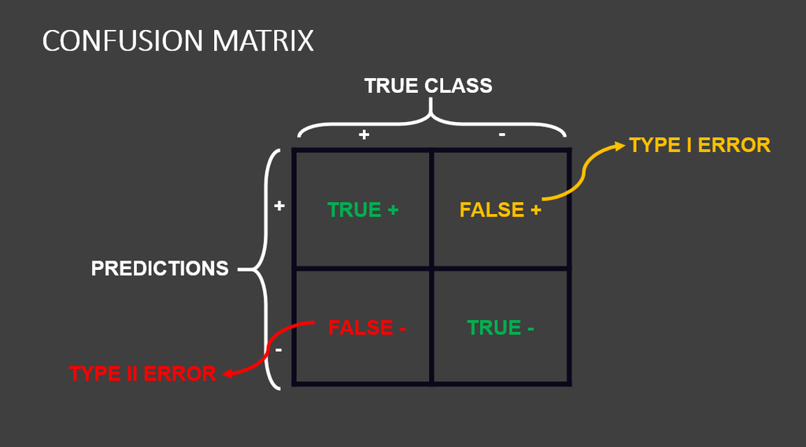

```python
score = cnn.evaluate(x_test, Y_test)
print('Test Accuracy: {}'.format(score[1]))
```

```
Test Accuracy: 0.8882026672363281
```

```python
history.history.keys()
```

```
dict_keys(['loss', 'accuracy', 'val_loss', 'val_accuracy'])
```

```python
accuracy = history.history['accuracy']
val_accuracy = history.history['val_accuracy']
loss = history.history['loss']
val_loss = history.history['val_loss']
```

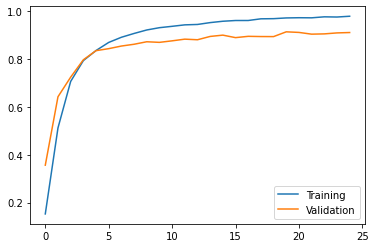

```python
import matplotlib.pyplot as plt
%matplotlib inline

plt.figure()
plt.plot(range(25),accuracy,label='Training')
plt.plot(range(25),val_accuracy,label='Validation')
plt.legend()
plt.show()
```

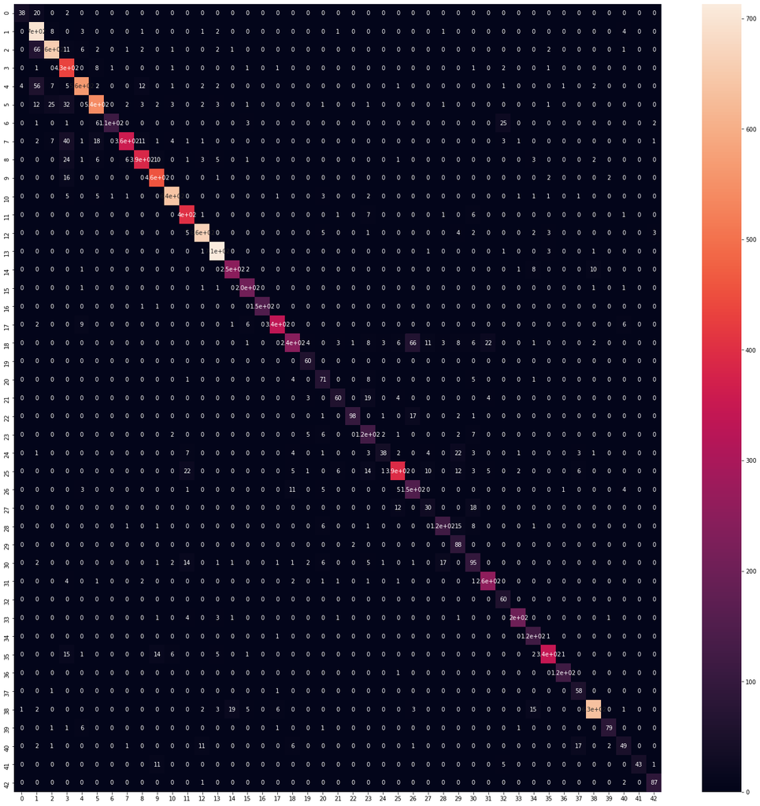

```python
predicted_classes =np.argmax(cnn.predict(x_test),axis=1)
y_true = Y_test

from sklearn.metrics import confusion_matrix
cm = confusion_matrix(y_true, predicted_classes)
plt.figure(figsize = (25, 25))
sns.heatmap(cm, annot = True)
```

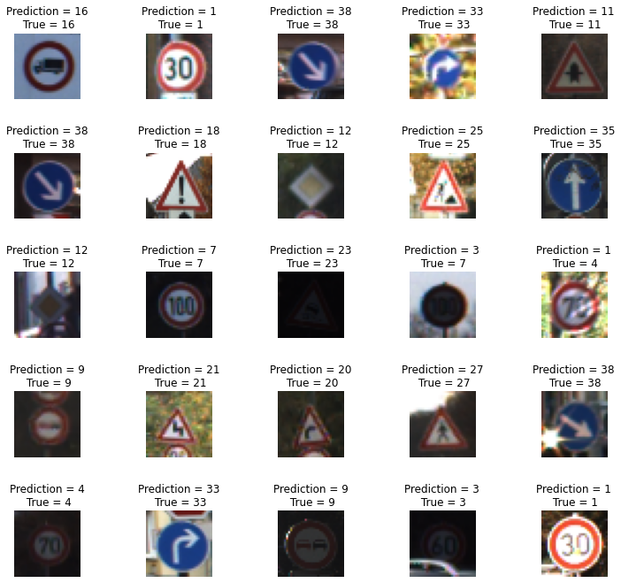

```python
L = 5
W = 5

fig, axes = plt.subplots(L, W, figsize = (12, 12))
axes = axes.ravel()

for i in np.arange(0, L*W):
    axes[i].imshow(X_test[i])
    axes[i].set_title('Prediction = {}\n True = {}'.format(predicted_classes[i], y_true[i]))
    axes[i].axis('off')

plt.subplots_adjust(wspace = 1)
```

# CONGRATULATIONS ON FINISHING THE PROJECT!

# APPENDIX

- In this case study, we want to classify images of traffic signs using deep Convolutional Neural Networks (CNNs).
- The dataset consists of 43 different classes of images.
- Classes are as listed below:
  - 0 = Speed limit (20km/h)
  - 1 = Speed limit (30km/h)
  - 2 = Speed limit (50km/h)
  - 3 = Speed limit (60km/h)
  - 4 = Speed limit (70km/h)
  - 5 = Speed limit (80km/h)
  - 6 = End of speed limit (80km/h)
  - 7 = Speed limit (100km/h)
  - 8 = Speed limit (120km/h)
  - 9 = No passing
  - 10 = No passing for vehicles over 3.5 metric tons
  - 11 = Right-of-way at the next intersection
  - 12 = Priority road
  - 13 = Yield
  - 14 = Stop
  - 15 = No vehicles
  - 16 = Vehicles over 3.5 metric tons prohibited
  - 17 = No entry
  - 18 = General caution
  - 19 = Dangerous curve to the left
  - 20 = Dangerous curve to the right
  - 21 = Double curve
  - 22 = Bumpy road
  - 23 = Slippery road
  - 24 = Road narrows on the right
  - 25 = Road work
  - 26 = Traffic signals
  - 27 = Pedestrians
  - 28 = Children crossing
  - 29 = Bicycles crossing
  - 30 = Beware of ice/snow
  - 31 = Wild animals crossing
  - 32 = End of all speed and passing limits
  - 33 = Turn right ahead
  - 34 = Turn left ahead
  - 35 = Ahead only
  - 36 = Go straight or right
  - 37 = Go straight or left
  - 38 = Keep right
  - 39 = Keep left
  - 40 = Roundabout mandatory
  - 41 = End of no passing
  - 42 = End of no passing by vehicles over 3.5 metric tons
- Citation J. Stallkamp, M. Schlipsing, J. Salmen, and C. Igel. The German Traffic Sign Recognition Benchmark: A multi-class classification competition. In Proceedings of the IEEE International Joint Conference on Neural Networks, pages 1453–1460. 2011. @inproceedings{Stallkamp-IJCNN-2011, author = {Johannes Stallkamp and Marc Schlipsing and Jan Salmen and Christian Igel}, booktitle = {IEEE International Joint Conference on Neural Networks}, title = {The {G}erman {T}raffic {S}ign {R}ecognition {B}enchmark: A multi-class classification competition}, year = {2011}, pages = {1453--1460} }